# Assignment 6: Visualization - Aesthetic Mapping

*How to do it?*:

- Open the Rmarkdown file of this assignment (link) in Rstudio.
- Right under each **question**, insert a code chunk (you can use the hotkey `Ctrl + Alt + I` to add a code chunk) and code the solution for the question.
- `Knit` the rmarkdown file (hotkey: `Ctrl + Alt + K`) to export an html.
- Publish the html file to your Githiub Page.

*Submission*: Submit the link on Github of the assignment to Canvas.

### Questions on Your Selected Data

Choose a dataset and produce the following types of plots and comment on each plot. Plots should be meaningful. If you use the data we used in class, make sure the plots are not the same as the ones in the slides.

1. For one continuous variable:

```r
setwd("C:\\Users\\student\\OneDrive - Bryant University\\Documents\\GitHub\\Math421")
df = read.csv('titanic.csv')
```

- Density

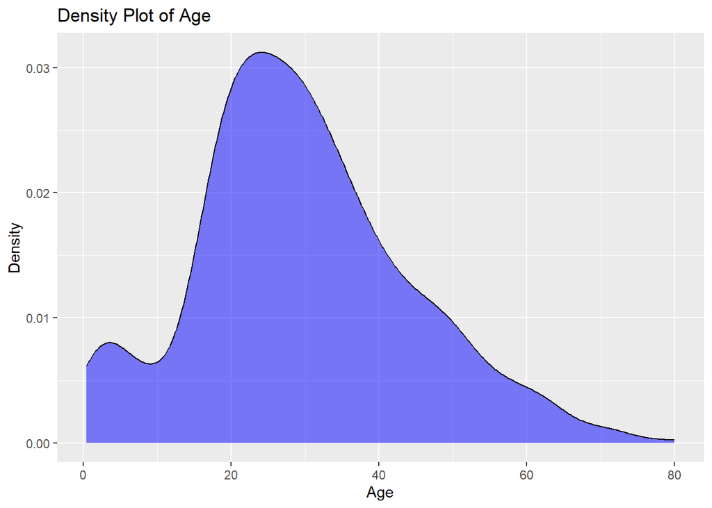

```r
library(ggplot2)
ggplot(df, aes(x=Age)) + geom_density(fill="blue", alpha=0.5) + labs(title="Density Plot of Age", x="Age", y="Density")
```

```r
# Comment: The density plot shows the distribution of ages among the Titanic passengers. It appears that most passengers were in their 20s and 30s, with a smaller number of older passengers.
```

- Histogram

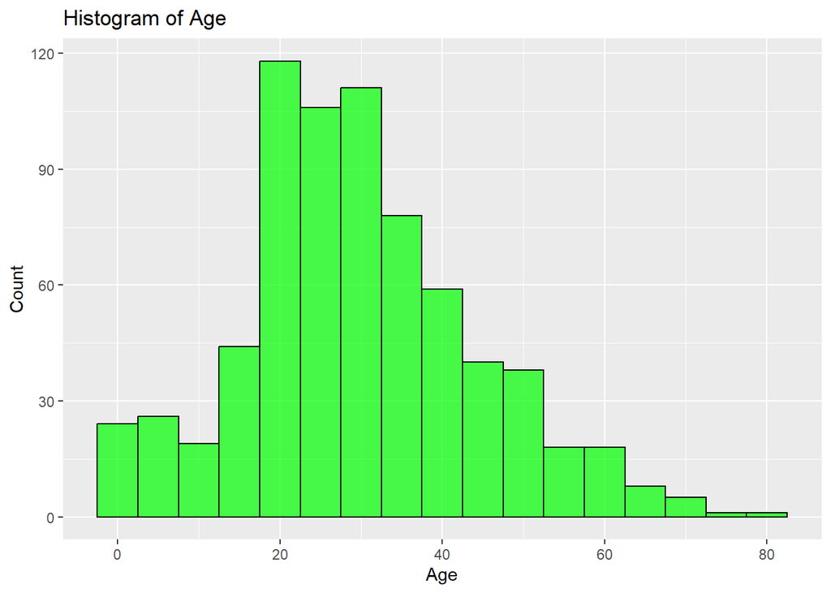

```r
ggplot(df, aes(x=Age)) + geom_histogram(binwidth=5, fill="green", color="black", alpha=0.7) + labs(title="Histogram of Age", x="Age", y="Count")
```

```r
# Comment: The histogram of ages shows the frequency distribution of passengers' ages. Similar to the plot above, it indicates that there is a higher concentration of passengers in the younger age groups, particularly between 20 and 40 years old.
```

- Boxplot

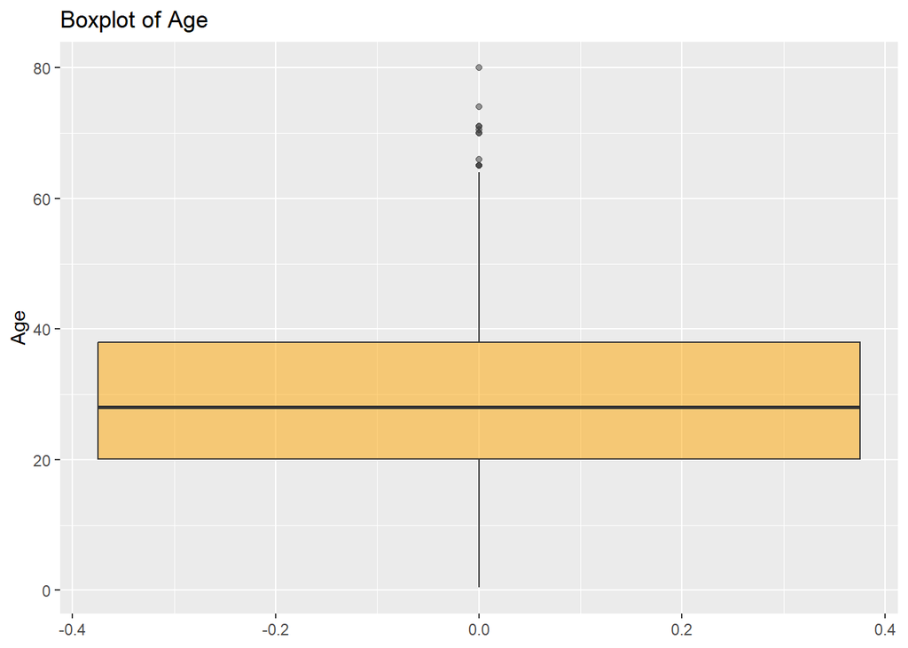

```r
ggplot(df, aes(y=Age)) + geom_boxplot(fill="orange", alpha=0.5) + labs(title="Boxplot of Age", y="Age")
```

```r
# Comment: The boxplot of ages reveals the median age, interquartile range, and potential outliers among the Titanic passengers. The median age is around 28 years, with some older passengers being outliers.
```

2. For one categorical variable
- Barplot

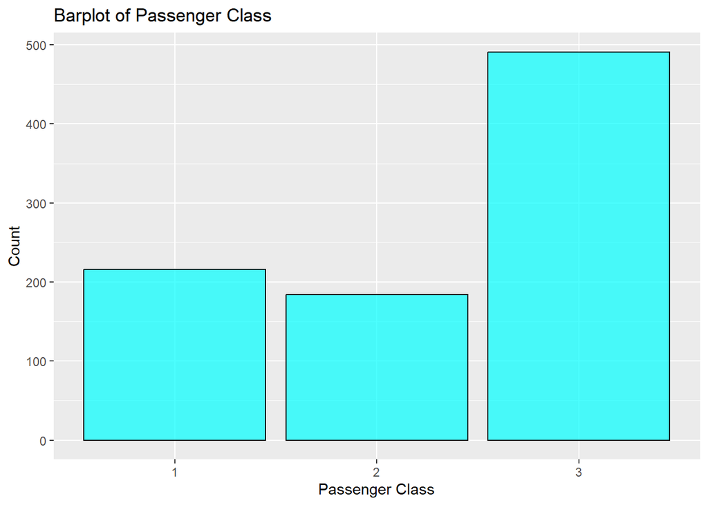

```r
ggplot(df, aes(x=as.factor(Pclass))) + geom_bar(fill="cyan", color="black", alpha=0.7) + labs(title="Barplot of Passenger Class", x="Passenger Class", y="Count")
```

```r
# Comment: The barplot shows the distribution of passengers across different classes. It is evident that the majority of passengers were in the 3rd class, followed by the 1st and 2nd classes.
```

3. For two continuous variables
- Scatter Plot

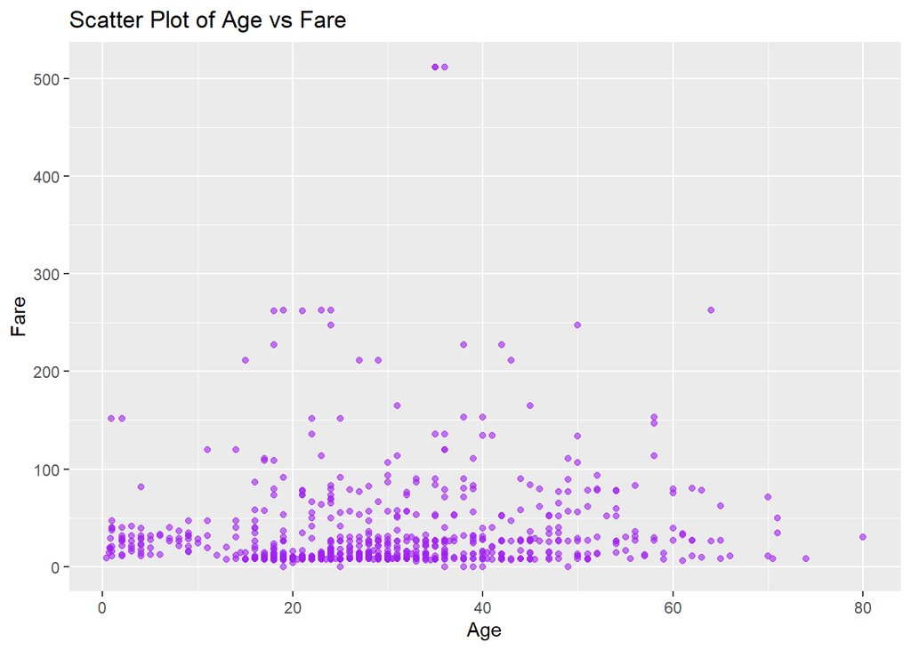

```r
ggplot(df, aes(x=Age, y=Fare)) + geom_point(color="purple", alpha=0.6) + labs(title="Scatter Plot of Age vs Fare", x="Age", y="Fare")
```

```r
# Comment: The scatter plot illustrates the relationship between passengers' ages and the fares they paid. There doesn't seem to be a strong correlation between age and fare, as passengers of all ages paid a wide range of fares.
```

- Line Plot

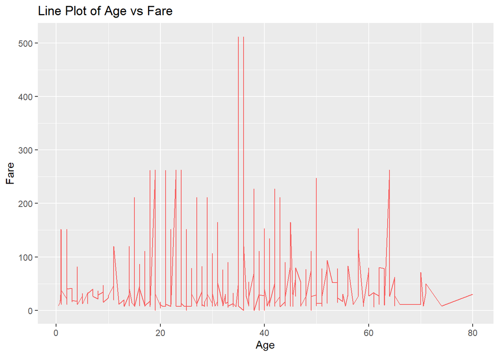

```r
ggplot(df, aes(x=Age, y=Fare)) + geom_line(color="red", alpha=0.6) + labs(title="Line Plot of Age vs Fare", x="Age", y="Fare")
```

```r
# Comment: The line plot connects the points of age and fare, but it is not very informative in this context since age is not a sequential variable. The plot does not reveal any clear trends or patterns.
```

- Smooth Plot

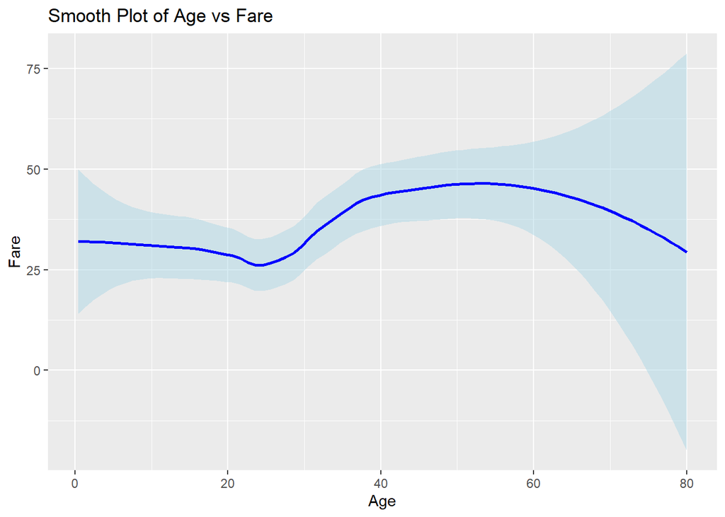

```r
ggplot(df, aes(x=Age, y=Fare)) + geom_smooth(method="loess", color="blue", fill="lightblue", alpha=0.5) + labs(title="Smooth Plot of Age vs Fare", x="Age", y="Fare")
```